# 数字经济发展与国家科技创新能力的关系分析

### 4.2.6 图6：数字基础设施变量相关性矩阵

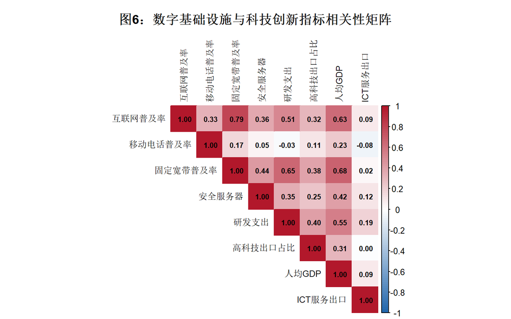

```r
cor_vars <- df_model %>%
  select(
    `互联网普及率` = `Individuals using the Internet (% of population)`,
    `移动电话普及率` = `Mobile cellular subscriptions (per 100 people)`,
    `固定宽带普及率` = `Fixed broadband subscriptions (per 100 people)`,
    `安全服务器` = `Secure Internet servers (per 1 million people)`,
    `研发支出` = `Research and development expenditure (% of GDP)`,
    `高科技出口占比` = `High-technology exports (% of manufactured exports)`,
    `人均GDP` = `GDP per capita (current US$)`,
    `ICT服务出口` = `ICT service exports (% of service exports, BoP)`
  )

cor_matrix <- cor(cor_vars, use = "pairwise.complete.obs")

corrplot(cor_matrix, method = "color", type = "upper",
         addCoef.col = "black", number.cex = 0.7,
         tl.col = "black", tl.cex = 0.8,
         title = "图6：数字基础设施与科技创新指标相关性矩阵",
         mar = c(0, 0, 3, 0),
         col = colorRampPalette(c("#2166AC", "white", "#B2182B"))(100))
```

# 5 深入分析：统计推断与建模

## 5.1 分析一：单因素方差分析（ANOVA）

**研究问题：** 不同收入组国家的数字化综合指数是否存在显著差异？

**原假设 H₀：** 四个收入组的数字化综合指数总体均值相等 **备择假设 H₁：** 至少有一个收入组的均值与其他组不同

```r
# 准备2022年数据
df_2022 <- df %>%
  filter(year == 2022, !is.na(income_group), !is.na(digital_index))

# 方差分析
anova_model <- aov(digital_index ~ income_group, data = df_2022)
anova_summary <- summary(anova_model)

# 输出ANOVA表
cat("=== 单因素方差分析（ANOVA） ===\n")
```

```
## === 单因素方差分析（ANOVA） ===
```

```r
cat("响应变量：数字化综合指数\n")
```

```
## 响应变量：数字化综合指数
```

```r
cat("因子：收入分组（4个水平）\n\n")
```

```
## 因子：收入分组（4个水平）
```

```r
print(anova_summary)
```

```
##               Df Sum Sq Mean Sq F value Pr(>F)
## income_group   3  40764   13588   83.59 <2e-16 ***
## Residuals    140  22756     163
## ---
## Signif. codes:  0 '***' 0.001 '**' 0.01 '*' 0.05 '.' 0.1 ' ' 1
```

```r
# 效应量（η²）
eta_sq <- summary(anova_model)[[1]]$`Sum Sq`[1] /
          sum(summary(anova_model)[[1]]$`Sum Sq`)
cat(sprintf("\n效应量 η² = %.4f\n", eta_sq))
```

```
##
## 效应量 η² = 0.6417
```

```r
# Tukey HSD 事后检验
cat("\n=== Tukey HSD 多重比较 ===\n")
```

```
##
## === Tukey HSD 多重比较 ===
```

```r
tukey_result <- TukeyHSD(anova_model)
print(tukey_result)
```

```
##   Tukey multiple comparisons of means
##     95% family-wise confidence level
##
## Fit: aov(formula = digital_index ~ income_group, data = df_2022)
##
## $income_group
##                        diff        lwr      upr     p adj
## 中低收入-低收入   27.046746 18.5655395 35.52795 0.0000000
## 中高收入-低收入   41.839744 32.5347217 51.14477 0.0000000
## 高收入-低收入     50.385887 41.6613638 59.11041 0.0000000
## 中高收入-中低收入 14.792998  7.1372600 22.44874 0.0000090
## 高收入-中低收入   23.339142 16.4005395 30.27774 0.0000000
## 高收入-中高收入    8.546143  0.6217011 16.47059 0.0290983
```

```r
# 提取关键值供文本引用
anova_fstat <- round(anova_summary[[1]][["F value"]][1], 2)
anova_pval <- anova_summary[[1]][["Pr(>F)"]][1]
eta_sq_pct <- round(eta_sq * 100, 0)
```

**检验结论：** - F统计量 = 83.59，p值 < 0.001，远小于显著性水平 α = 0.05 - **拒绝原假设**，四个收入组之间的数字化综合指数存在极显著差异 - 效应量 η² ≈ 0.642，属于大效应（>0.14），说明收入分组解释了数字化差异的大约 64% - Tukey HSD 事后检验表明，**所有两两比较均显著**，四个收入组两两之间均存在显著差异 - **业务结论：** 国家经济发展水平是数字基础设施差异的关键解释因素，弥合数字鸿沟需要针对不同发展阶段采取差异化政策

## 5.2 分析二：多元线性回归模型

**研究问题：** 数字基础设施指标和经济发展水平是否能显著预测一国的高科技出口能力？

```r
# 构建回归模型
lm_model <- lm(
  `High-technology exports (% of manufactured exports)` ~
    `Individuals using the Internet (% of population)` +
    `Research and development expenditure (% of GDP)` +
    `GDP per capita (current US$)` +
    `Fixed broadband subscriptions (per 100 people)`,
  data = df_model
)

# 模型摘要
cat("=== 多元线性回归模型 ===\n")
```

```
## === 多元线性回归模型 ===
```

```r
cat("因变量：高科技出口占制成品出口比重（%）\n\n")
```

```
## 因变量：高科技出口占制成品出口比重（%）
```

```r
summary(lm_model)
```

```
##
## Call:
## lm(formula = `High-technology exports (% of manufactured exports)` ~
##     `Individuals using the Internet (% of population)` + `Research and development expenditure (% of GDP)` +
##         `GDP per capita (current US$)` + `Fixed broadband subscriptions (per 100 people)`,
##     data = df_model)
##
## Residuals:
##     Min      1Q  Median      3Q     Max
## -14.814  -6.394  -2.666   2.353  56.168
##
## Coefficients:
##                                                     Estimate Std. Error t value
## (Intercept)                                        5.221e+00  1.023e+00   5.102
## `Individuals using the Internet (% of population)` 1.883e-02  2.222e-02   0.847
## `Research and development expenditure (% of GDP)`  2.827e+00  4.001e-01   7.064
## `GDP per capita (current US$)`                     1.383e-05  1.876e-05   0.737
## `Fixed broadband subscriptions (per 100 people)`   1.437e-01  4.603e-02   3.122
##                                                    Pr(>|t|)
## (Intercept)                                        3.96e-07 ***
## `Individuals using the Internet (% of population)`  0.39692
## `Research and development expenditure (% of GDP)`  2.88e-12 ***
## `GDP per capita (current US$)`                      0.46132
## `Fixed broadband subscriptions (per 100 people)`    0.00185 **
## ---
## Signif. codes:  0 '***' 0.001 '**' 0.01 '*' 0.05 '.' 0.1 ' ' 1
##
## Residual standard error: 10.5 on 1093 degrees of freedom
##   (6 observations deleted due to missingness)
## Multiple R-squared:  0.1875, Adjusted R-squared:  0.1845
## F-statistic: 63.06 on 4 and 1093 DF,  p-value: < 2.2e-16
```

```r
# 标准化系数（比较各变量相对重要性）
cat("\n=== 标准化回归系数（Beta） ===\n")
```

```
##
## === 标准化回归系数（Beta） ===
```

```r
df_std <- df_model %>%
  mutate(across(where(is.numeric), ~ as.numeric(scale(.))))
lm_std <- lm(
  `High-technology exports (% of manufactured exports)` ~
    `Individuals using the Internet (% of population)` +
    `Research and development expenditure (% of GDP)` +
    `GDP per capita (current US$)` +
    `Fixed broadband subscriptions (per 100 people)`,
  data = df_std
)
print(coef(lm_std))
```

```
##                                        (Intercept)
##                                        0.002448944
## `Individuals using the Internet (% of population)`
##                                        0.038852977
##  `Research and development expenditure (% of GDP)`
##                                        0.259476069
##                     `GDP per capita (current US$)`
##                                        0.028743087
##   `Fixed broadband subscriptions (per 100 people)`
##                                        0.163352601
```

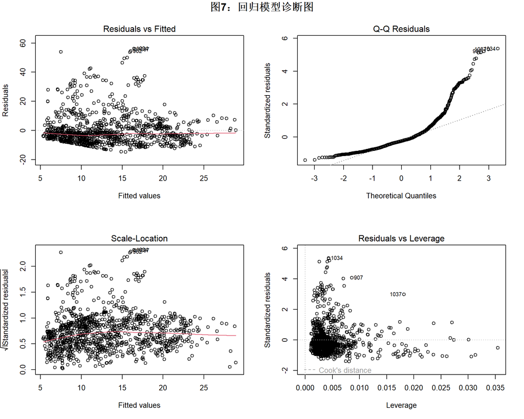

```r
# 模型诊断图
par(mfrow = c(2, 2))
plot(lm_model)
par(mfrow = c(1, 1))
title("图7：回归模型诊断图", line = -1, outer = TRUE)
```

# 6 结论与反思

1. **缺失数据问题。** 低收入国家的研发支出和专利申请数据缺失严重，可能导致选择偏差。
2. **相关性不等于因果性。** 回归分析揭示关联关系，但不能直接推断因果关系。
3. **指标局限性。** 互联网普及率无法完全反映”数字素养”和”数字服务质量”等深层次维度。
4. **国家层面数据的异质性。** 国家内部不同地区和群体之间可能存在巨大差异被均值掩盖。

## 6.3 改进方向

1. 引入更多控制变量（教育水平、制度质量、开放度等）构建更全面的模型
2. 使用面板数据固定效应模型控制国家不可观测特征
3. 将分析下沉到行业/企业层面，获取更细致的数据
4. 引入因果推断方法（如工具变量、双重差分）增强因果论证

# 7 附录

## 7.1 团队分工表

[output not shown]

*注：实际填写时请替换为真实姓名并如实记录贡献。*

## 7.2 数据来源说明

- **数据集名称：** World Bank Indicators (1960-Present)
- **Kaggle链接：** https://www.kaggle.com/datasets/georgejdinicola/world-bank-indicators
- **原始数据来源：** World Bank Open Data (https://data.worldbank.org/)
- **数据许可：** CC BY 4.0
- **变量数：** 16个（精选自800+指标）
- **观测数：** 3,440条（251国家 × 2010-2024）
- **R包依赖：** tidyverse, corrplot, car, scales, broom, knitr

## 7.3 复现说明

1. 确保已安装所有依赖包：`install.packages(c("tidyverse", "corrplot", "car", "scales", "broom"))`
2. 将 `data/digital_economy_innovation.csv` 放在 `report.Rmd` 同级目录的 `data/` 子目录下
3. 在 RStudio 中打开 `report.Rmd`，点击 **Knit** 按钮即可生成 HTML 报告
4. 全文代码块可无错误运行，输出完全可复现

*本报告使用 R Markdown 撰写，所有分析代码和可视化结果均可复现。*